# prob5

```python
from IPython.display import display, Image
```

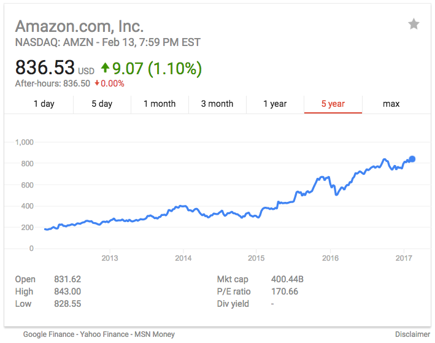

```python
display(Image(filename='amzn.png'))
```

(1) 1D Time Series:

The graph above shows the stock of Amazon (AMZN) over a period of 5 years. There is only one time axis in this graph, and therefore it's 1D Time Series.

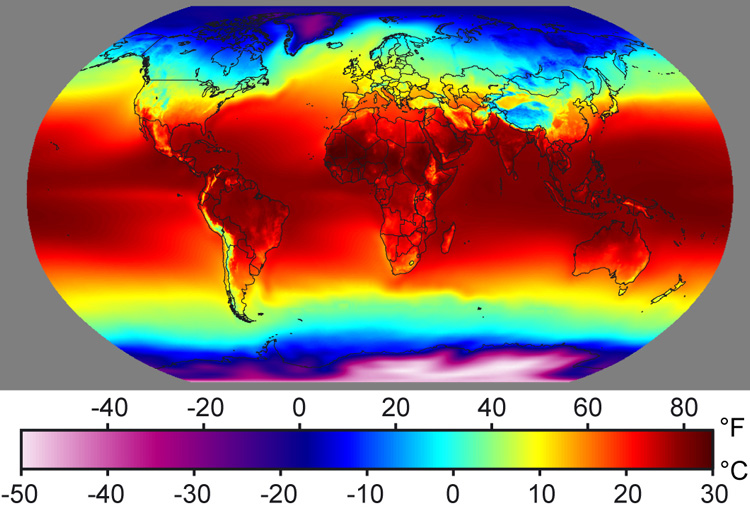

```python
display(Image(filename='earth.jpg'))
```

(2) 2D Scaler Field:

The image above presents the annual mean temprature of earth. It's 2D because every point on the map combines the location and the temprature together.

[figure not shown]

```python
display(Image(filename='temp3d.jpg'))
```

(3) 3D Scaler Field:

The website http://www.meteoearth.com/ let you see several meteorological categories of earth. The figure shows the temprature of a specifiec time and date, and how it looks on earth. In other words, there is temprature and location again, but this time it's presented on a 3D image.

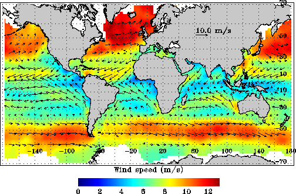

```python
display(Image(filename='wind2d.png'))
```

In this figure, the speed and the direction of the wind are presented on the map. The magnitude and the direction of the wind combined with the location on the map, and therefore it's 2D vector field.

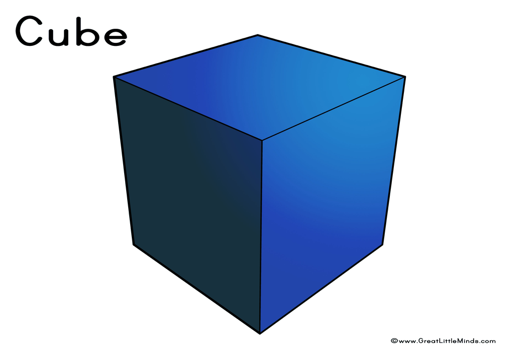

```python
display(Image(filename='cube.jpg'))
```

(5) 3D shape

This figure is in three dimentions. The width, height and depth can be seen

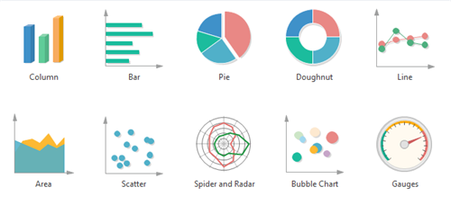

```python
display(Image(filename='graphs.png'))
```

(6) Graphs

In the figure above, there are few types of graphs such as Column graph, Bar graph, Pie graph etc.